# Facebook Stock Analysis

## Hypothesis Testing

The experiment we want to try is whether the stock will go up or not. We believe that the stock will go up - let’s test this!

First, we measure the number of days the stock goes up/even and down.

```r
going_up <- sum(fb_df_diff$Close_Open_Diff >= 0) #seeing how days are positive
going_up
```

```
## [1] 391
```

```r
going_down <- sum(fb_df_diff$Close_Open_Diff < 0) #seeing how many days are negative
going_down
```

```
## [1] 365
```

Without any knowledge, let’s assume the probability of the stock going up is $p_A$ = 0.5. We want to estimate $p_B$, the probability of the stock going up.

The total number of days is 756. The number of days that the stock goes up is 391. We will treat this as n = 756 draws from Bernoulli(.5) random variable and use the sample mean $\bar{X}$ as 391/756 as the estimate $\hat{p_B}$. The sample mean is this because $\frac{1}{n} \sum\limits_{i=1}^n X_i = \frac{1}{756} * 391$. If you do not completely understand this, you can read more about Bernoulli here: https://en.wikipedia.org/wiki/Bernoulli_distribution !

We will test the null hypothesis $p_B <= p_A$ and reject it if $p(\bar{X} > \hat{p_B}) <= \alpha$ where alpha (0.05 in this case) is our rejection level.

To do this, we need to calculate $E\bar{X}$ and $Var(\bar{X})$. By deriving these with the sample mean, we get $E\bar{X} = p_A$ and $Var(\bar{X}) = \frac{p_A(1-p_A)}{n}$.

Now we can use R to calculate these.

```r
#creating functions to calculate these values
E <- function(n, pA) {
  pA
}
valueE <- E(756, 0.5) #calling function

Var <- function(n, pA) {
  pA * (1- pA) / n
}
valueVar <- Var(756, 0.5) #calling function

valueE
```

```
## [1] 0.5
```

```r
valueVar
```

```
## [1] 0.0003306878
```

We can see that $E\bar{X} = 0.5$ and $Var(\bar{X}) = 0.0003306878$

Now we can compute $p(\bar{X} > \hat{p_B})$ using the function pnorm. Learn more about it here http://seankross.com/notes/dpqr/ .

Remember, $\hat{p_B}$ = 391/756

```r
pB = 391/756
prob <- pnorm(pB, mean = valueE, sd = sqrt(valueVar), lower.tail = FALSE)
prob
```

```
## [1] 0.1721736
```

Let’s see if this changes when n is a smaller number and also when its larger!

```r
valueE2 <- E(600, 0.5)

valueVar2 <- Var(600, 0.5)

valueE2
```

```
## [1] 0.5
```

```r
valueVar2
```

```
## [1] 0.0004166667
```

```r
pB2 = 391/600
prob2 <- pnorm(pB2, mean = valueE2, sd = sqrt(valueVar2), lower.tail = FALSE)
prob2
```

```
## [1] 5.425006e-14
```

```r
valueE3 <- E(900, 0.5)

valueVar3 <- Var(900, 0.5)

valueE3
```

```
## [1] 0.5
```

```r
valueVar3
```

```
## [1] 0.0002777778
```

```r
pB3 = 391/900
prob3 <- pnorm(pB3, mean = valueE3, sd = sqrt(valueVar3), lower.tail = FALSE)
prob3
```

```
## [1] 0.9999581
```

Looking at these results, we can reject when n = 600 but can’t reject when n = 900.

Now that we have done hypothesis testing, let’s delve into some machine learning.

## Machine Learning

One of the most common examples of machine learning is linear regression. It models the relationship between two models by fitting a linear equation to observed data. An example of this was presented earlier on with a regression line that showed the relationship between Date and Closing Price. Go to this link if you want more information! https://en.wikipedia.org/wiki/Linear_regression

Let’s first look at the distribution of the closing price across years to get a general feel for the data:

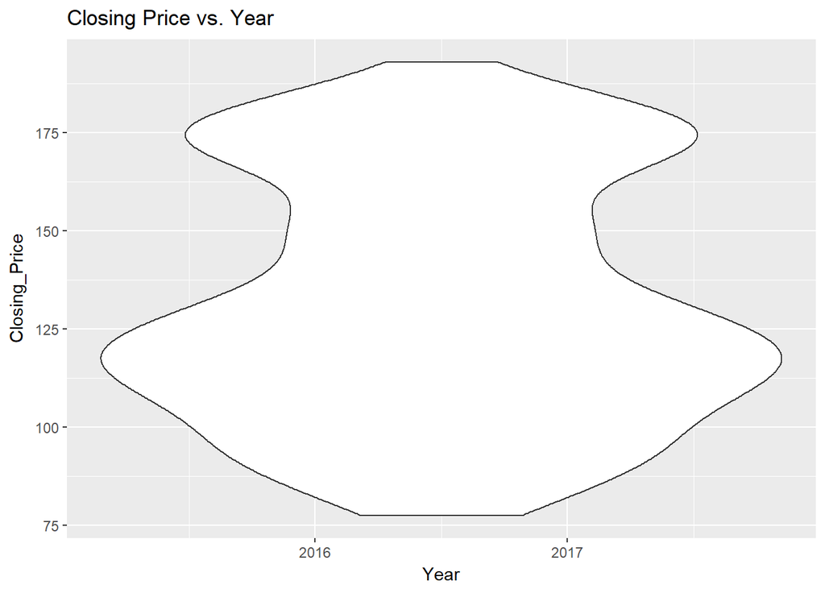

```r
fb_df_diff %>%
  ggplot(aes(x=Year, y=Closing_Price)) +
  geom_violin() + #type of plot is violin
  labs(title="Closing Price vs. Year")
```

We see that most prices are around the $125 range.

Now, let’s build a linear model between Closing Price and Year to help us predict the price of the stock in the future.

```r
fb_fit <- lm(Closing_Price~Year, data = fb_df_diff) #linear model for Closing_Price and Year
fb_fit %>%
  tidy()
```

```
##          term     estimate    std.error statistic       p.value
## 1 (Intercept) -59864.96042 1029.7318937 -58.13645 8.130006e-281
## 2        Year     29.75524    0.5106909  58.26469 2.088221e-281
```

From this, we can see that the stock grows by about $29.75524 per year!

We can also look at the residuals for more information. Residuals are basically the difference between the observed value of the dependent variable and the predicted value. We can look at these using the augment() function.

```r
fb_fit %>%
  augment() %>% #augmenting to see more information about the model
  as_data_frame()
```

```
## # A tibble: 756 x 9
##    Closing_Price  Year .fitted .se.fit .resid    .hat .sigma   .cooksd
##            <dbl> <int>   <dbl>   <dbl>  <dbl>   <dbl>  <dbl>     <dbl>
##  1           183  2018     181   0.971   1.54 0.00534   13.3 0.0000360
##  2           179  2018     181   0.971  -2.20 0.00534   13.3 0.0000740
##  3           178  2018     181   0.971  -3.15 0.00534   13.3 0.000152
##  4           177  2018     181   0.971  -4.51 0.00534   13.3 0.000310
##  5           174  2018     181   0.971  -7.10 0.00534   13.3 0.000769
##  6           176  2018     181   0.971  -5.05 0.00534   13.3 0.000389
##  7           174  2018     181   0.971  -7.26 0.00534   13.3 0.000804
##  8           172  2018     181   0.971  -9.12 0.00534   13.3 0.00127
##  9           174  2018     181   0.971  -7.53 0.00534   13.3 0.000865
## 10           174  2018     181   0.971  -6.96 0.00534   13.3 0.000739
## # ... with 746 more rows, and 1 more variable: .std.resid <dbl>
```

Let’s also plot them for better visualization.

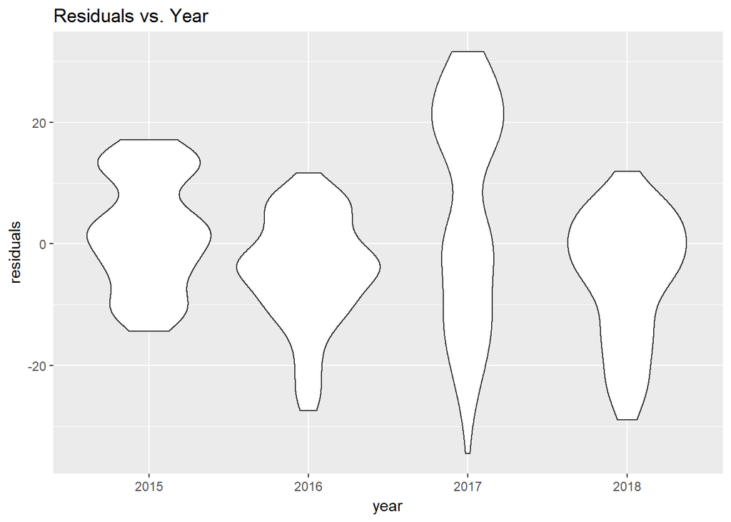

```r
fb_fit %>%
  augment() %>%
  ggplot(aes(x=factor(Year), y=.resid)) + #residuals are the y axis
  geom_violin() +
  labs(title="Residuals vs. Year", x = "year", y = "residuals")
```

These violins help us see what the distribution of residuals across the years!

We can also use a linear model to predict the price in the next month!

```r
df_model <- fb_df_diff %>%
  mutate(yearMon = paste(Month, "- 01 -", Year )) %>% #making a new column for year months
  mutate(yearMon=as.Date(yearMon, format = "%m - %d - %Y")) #converting it to a date object

fb_fit <- lm(Closing_Price~yearMon, data = df_model) #linear model
fb_fit %>%
  tidy()
```

```
##          term      estimate    std.error statistic p.value
## 1 (Intercept) -1.492125e+03 1.589333e+01 -93.88373       0
## 2     yearMon  9.499385e-02 9.294052e-04 102.20929       0
```

We can add interactions between columns to see how their interaction affects the Closing_Price. Let’s make one with Year and Volume_of_Shares_Traded and also plot the residuals using the same steps as before. Visit this link if you have trouble understanding interactions: https://cran.r-project.org/web/packages/jtools/vignettes/interactions.html

```r
fb_fit_int <- lm(Closing_Price~Year*Volume_of_Shares_Traded, data = fb_df_diff) #adding interactions using "*"
fb_fit_int %>%
  tidy()
```

```
##                           term      estimate    std.error  statistic
## 1                  (Intercept) -6.286782e+04 1.903243e+03 -33.031950
## 2                         Year  3.124739e+01 9.437759e-01  33.108906
## 3      Volume_of_Shares_Traded  1.323170e-04 5.842370e-05   2.264784
## 4 Year:Volume_of_Shares_Traded -6.574509e-08 2.897009e-08  -2.269413
##         p.value
## 1 1.540966e-148
## 2 5.458204e-149
## 3  2.380977e-02
## 4  2.352563e-02
```

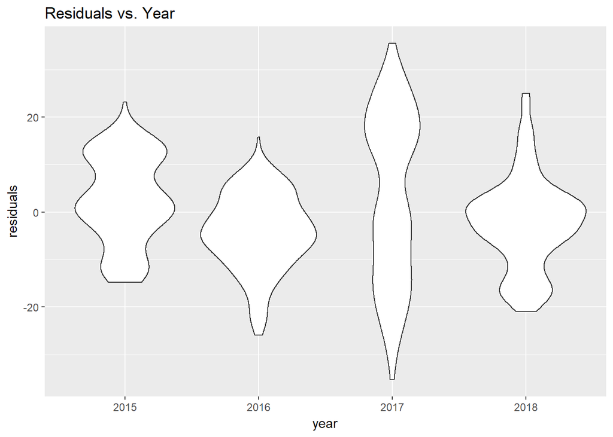

```r
fb_fit_int %>%
  augment() %>%
  ggplot(aes(x=factor(Year), y=.resid)) +
  geom_violin() +
  labs(title="Residuals vs. Year", x = "year", y = "residuals")
```

We can use also multiple logistic regression to see if different predictors can cause the stock to go up or down

```r
log_fb_df <- fb_df_diff %>%
  mutate(rising = Close_Open_Diff > 0) #making a logical column to see it it rises

#logistic regression with multiple predictors
log_r <- glm(rising ~ Year + Volume_of_Shares_Traded + Opening_Price, data=log_fb_df, family="binomial")
log_r %>%
  tidy() %>%
  knitr::kable(digits=4)
```

| term | estimate | std.error | statistic | p.value |
| --- | --- | --- | --- | --- |
| (Intercept) | -784.5690 | 374.9173 | -2.0926 | 0.0364 |
| Year | 0.3902 | 0.1863 | 2.0942 | 0.0362 |
| Volume_of_Shares_Traded | 0.0000 | 0.0000 | -1.0857 | 0.2776 |
| Opening_Price | -0.0145 | 0.0058 | -2.5134 | 0.0120 |

Next, we can look at Trees to even further analyze this data set. If you have never seen trees before, take a glance at https://cran.r-project.org/web/packages/tree/tree.pdf to understand a bit before we delve into examples.

Using a regression tree based on Closing_Price and Month, we can determine stock prices.

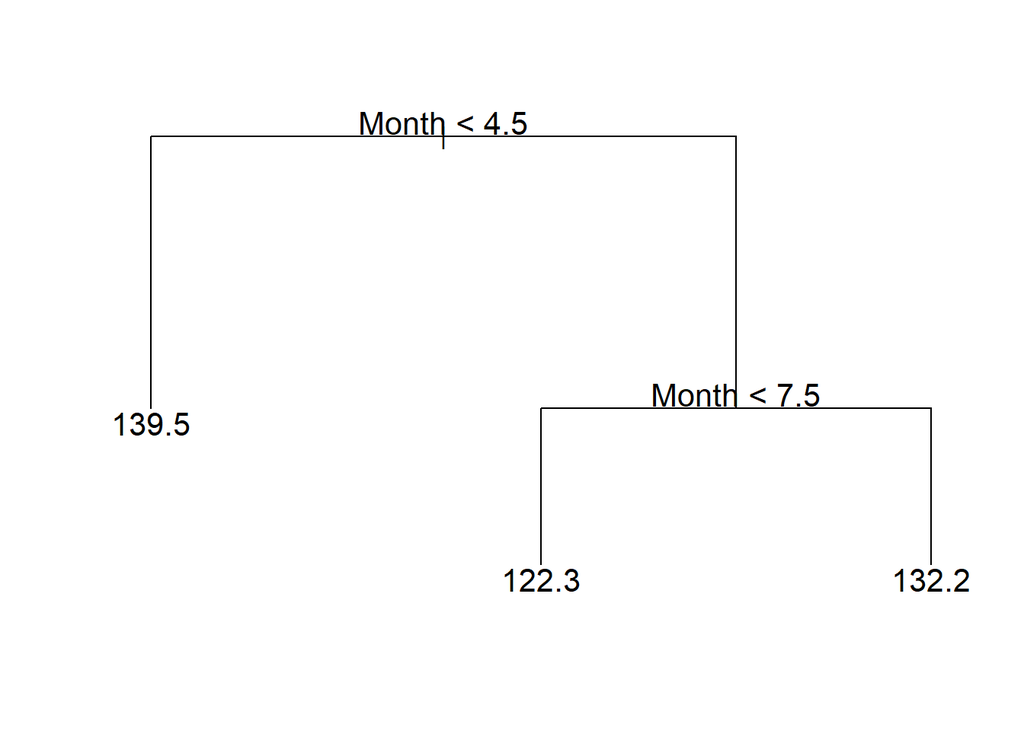

```r
tree <- tree(Closing_Price~Month, data=fb_df_diff) #creating a tree
plot(tree)
text(tree, pretty=0, cex=1.3)
```

This indicates that Months less than 4.5 (January - mid April) tend to have a price around 139.5. Months greater than 4.5 and less 7.5 (mid April - mid July) tend to have prices around 122.3 and months greater than 4.5 and greater than 7.5 (mid July - December) have a price around 132.2.

This lets the investor know that the best time to buy the stock is right before January and hold the stock until mid April. The time to avoid the stock is (mid April - mid July)! Using this regression tree, the investor can also tell that the best time to sell is mid April.

We can also see how the volume changes per month:

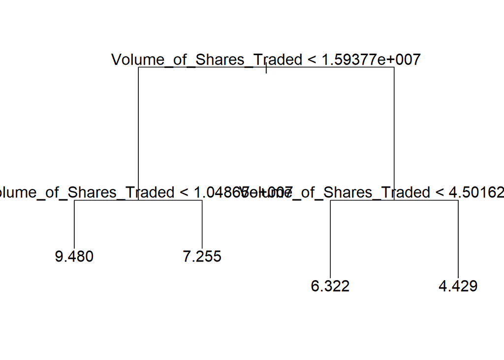

```r
tree <- tree(Month~Volume_of_Shares_Traded, data=fb_df_diff)
plot(tree)
text(tree, pretty=0, cex=1.3)
```

Using a decision tree with predictors Month and Year gives us a more descriptive tree of estimated prices!

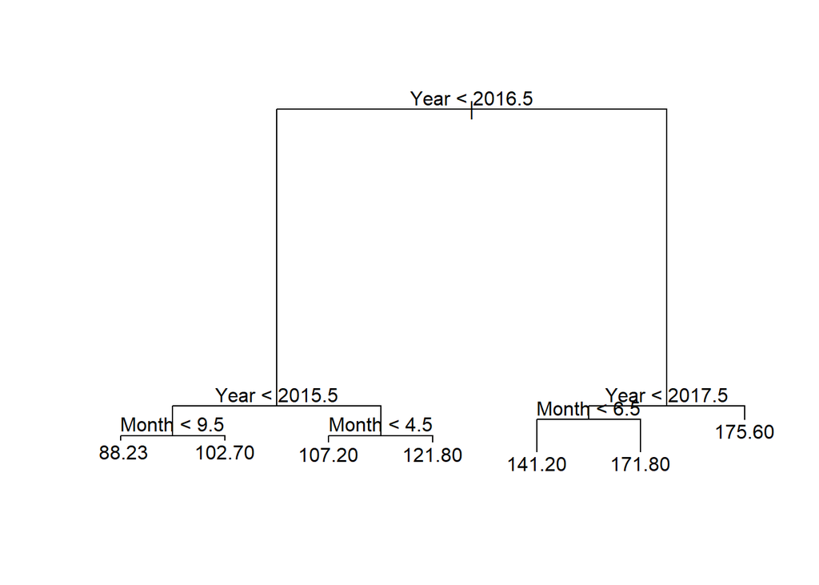

```r
tree <- tree(Closing_Price~Month+Year, data=fb_df_diff)
plot(tree)
text(tree, pretty=0)
```

Looking at this, we can see how the price has increased throughout the years!

We can do the same thing but add a another column for percent change:

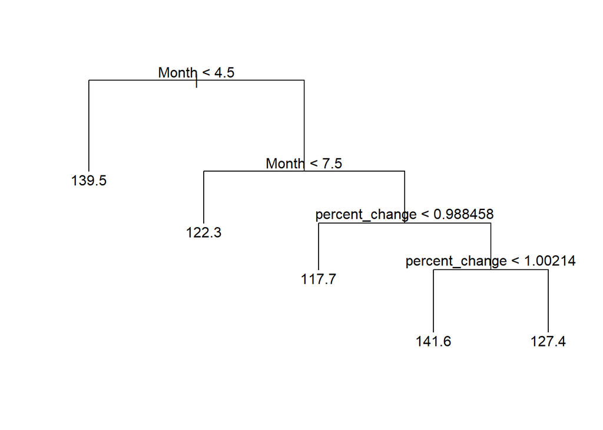

```r
fb_tree <- fb_df_diff %>%
  mutate(percent_change = Closing_Price/Opening_Price) %>% #creating a column for percent change:: Closing/Opening price
  select(Closing_Price, Year,Month, percent_change)

tree <- tree(Closing_Price~Month+percent_change, data=fb_tree)
plot(tree)
text(tree, pretty=0)
```

The best stock prices occur after mid July and when the percent change is less than 1.00214. This is an indication of when to sell to maximize profit.

If you had trouble understanding trees, you can visit http://www.stat.wisc.edu/~loh/treeprogs/guide/wires11.pdf to learn more.

## Conclusion

This topic is important because so many people today are involved in stock trading and many people are paying top dollar to get investment advice. With stock data analysis, it is possible to optimize as much profit as possible. This is important in general because it can help people make money and contribute towards a sustainable market. This topic is important in regards to data science because stock data analysis can bring about a whole new understanding to the stock market - and data scientists can pave the way towards this. It can predict the future of the US market and many people are involved in using big data to analyze stocks. Stock data provides a lot of potential for data analysis there are so many ways to analyze it to come up with different kinds of predictions.

Through all the methods done in this walk through, we were able to determine how to interpret stock data, which exact months the stock would go up or down, when it was a good time to sell the stock, what indicators would make a stock go down, what the price would be in the future, which predictors affect whether it goes up or down, which plays are best to make for each month, and how the stock changes throughout the years. Through all of this, the reader can determine that Facebook is in fact a good stock to buy and now knows which time is best to sell in order to make as much as possible!

There have been many techniques learned such as data curation, parsing, management, exploratory data analysis, hypothesis testing, and machine learning. Through these techniques, the reader has now gained the skills to analyze and understand stock data more than they have before - they can now use data science to predict what the stock price will be in the future and know how to maximize profit! Along with this, they have learned the process in selecting a data set, analyzing it through the creation of plots, trees, etc., creating predictions, and then finally drawing a conclusion from it. After reading this walk through, the user has gained skills and knowledge that will allow them to analyze many other data sets and draw conclusions from them!